# Datenprojekte im R tidyverse

Prof. Dr. Jörg Schoder

2023-07-28

# 1 Überblick Datenprojekte

- Datenprojekte…
  - …sind Projekte, bei denen Daten gesammelt, analysiert und interpretiert werden, um bestimmte Ziele zu erreichen.
  - … können verschiedene Formen annehmen, darunter wissenschaftliche Forschungsstudien, Marktanalysen, Geschäftsdatenanalysen und vieles mehr.
  - durchlaufen typischerweise verschiedene Phasen (s.u.).
- Für Unternehmen und Organisationen spielen Datenprojekte eine immer wichtigere Rolle, weil sie für fundierte Entscheidungen und Einblicke in komplexe Fragestellungen zunehmend auf Daten angewiesen sind.
- Statistik und Software sind für erfolgreiche Datenprojekte unverzichtbar
  - Mit Hilfe statistischer Verfahren können in den gesammelten Daten sinnvolle Muster und Trends erkannt werden.
  - Software ist Voraussetzung für eine effiziente (ggf. sogar automatisierte) des gesamten Datenprojekts (s.u.).

## 1.1 Phasen und Ablauf von Datenprojekten

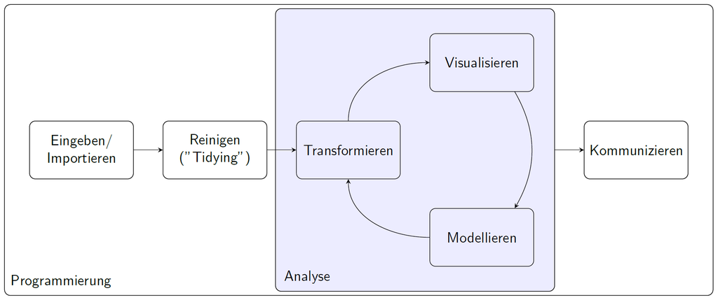

Data Science Workflow. Eigene Darstellung.

## 1.2 Datenprojekte im -tidyverse

### 1.2.1 Grundidee des “tidyverse”

- Hadley Wickham und anderen Entwickler haben eine Sammlung von -Paketen mit einer “gemeinsamen und v.a. **intuitiven** Grundlogik” (Syntax) als [tidyverse](https://www.tidyverse.org/) etabliert.
- Vorstellung: als Sprache, *tidyverse* als Dialekt.
- **Kernphilosophie:** Effizientiere, konsistentere und **intuitivere** Gestaltung von Datenanalysen durch…
  - …Organisation von Daten in **“tidy”**-Form
  - …klarere und kompaktere Code-Struktur. Diese wird ermöglicht durch…
    - …Einsatz funktionaler Programmierung und anwendungsspezifischer Funktionen (sogenannten “Verben” wie filter(), mutate(), select() usw.) anstelle von komplexen Schleifen.
  - …Pipes (`%>%`), um den Output einer Funktion direkt als Input für die nächste Funktion zu verwenden.

**Kurz:** Klare und intuitive Syntax mit intuitiven Funktionsnamen (“Verben”).

### 1.2.2 tidyverse-Pakete im Verlauf eines Datenprojekts

- Überblick über tidyverse-kompatible Pakete, die in den verschiedenen Phasen eines Datenprojekts hilfreich sind

[figure not shown]

Überblick R tidyverse. Quelle: [storybench.org](https://www.storybench.org/getting-started-with-tidyverse-in-r/).

- **tidyverse**-Bibliothek als “Metapaket”: Mit `library(tidyverse)` werden automatisch die wichtigsten tidyverse-Pakete geladen:
- Das **tibble**-Paket - stellt via `tibble()`-Funktion eine Datenstruktur bereit
- Das **readr**-Paket - stellt diverse Funktionen wie bspw. `read_csv()` zum Einlesen rechteckiger Daten aus durch Trennzeichen getrennten Dateien (.csv,.tsv, etc.) zur Verfügung.
- Das **tidyr**- und das **dplyr**-Paket zur Datentransformation und -modifikation
- Das **stringr**-, das **forcats**- und das **lubridate**-Paket für die Arbeit mit speziellen Objekttypen:
  - **stringr** für die Arbeit mit Textobjekten
  - **forcats** für die Arbeit mit Faktoren
  - **lubridate** für die Arbeit mit Zeitdaten
- das **purrr**-Pakete für funktionelles Programmieren
- das **ggplot**-Paket für die Datenvisualierung

Neben dem **purrr**-Paket spielt für die Praxis in Sachen Programmierung noch das **glue**-Paket eine Rolle, das (als Alternative zur paste()-Funktion) die Möglichkeit bietet Daten/Zahlen und strings zu verbinden.